# Do William Shakespeare’s men and women employ significantly different diction?

Simran Vatsa, 804644668, ENGL 150, Prof. Robert Watson

3/25/2018

### Introduction:

I’ve been quite interested in the potential of text data-mining for about three months now, so I’ve been reading articles, blog posts and studies that explore or demonstrate it. I’ve gathered that it gives one the ability to distant-read a corpus in ways human reading and language processing cannot. Humans are best at processing small amounts of information at a time; but for machines, the larger the corpus, the more likely it is that useful, interesting insights will be produced. With this in mind, I kept my research question quite broad: *Do William Shakespeare’s men and women employ significantly different diction?*

Technologically (and theoretically), I’m very far from an expert on natural language processing, so this project is far less incisive that it could have been in someone else’s hands. For instance, I’ve read papers on machines predicting gender from dialogue. I admittedly do not have the knowledge to code something like that (I hope to soon though!), so I wanted to use this project to solidify and apply some basic techniques I’ve read about.

### The cleaning process:

I attempted to download the plays from Gutenberg, but they were quite messy; while tokenizing and tidying was not difficult, there was no convenient way to assign speaker names and play line numbers to each line or word. I was thus happy to find a dataset of Shakespeare’s plays on Kaggle, with the following variables:

*Dataline: row number in dataset*

*Play: name of play*

*PlayerLinenumber: represents the nth change in speaker*

*ActSceneLine: the play’s act, scene and line number, as seen in physical copies*

*Player: character speaking the corresponding line of speech*

*PlayerLine: text of the play, line by line*

The dataset first contained all Shakespeare’s known works. I filtered it to include just six of the eight plays we read in class. I then tokenized the variable PlayerLine into single words, labelling the variable “word.” Tokenizing converts data to tidytext format, the most convenient way to analyze text in R.

### How often do men and women each speak?

```
## Number of characters in the six plays: 166
```

```
## Number of each gender:
## Female: 26 Male: 134
```

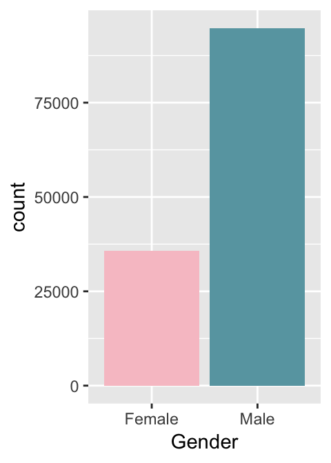

Next, I removed stop words from the dataset, adding common archaic words to the modern English corpus of stop words after some exploration of the data. The ratio of men’s words to women’s remained around the same, 2.76. Dividing the number of significant words said by number of characters for each gender showed each woman was given a good deal more significant words on average. This is a result of most auxillary characters being male; if a woman features, she is usually important to the plot, or important to a woman who is important to the plot: Juliet’s nurse, Celia in “As You Like It” and Nerissa in “The Merchant of Venice” are all examples of the latter. When coding gender to character names, written in order of appearance, it was interesting to note that very often, when one woman appeared, another often followed immediately. This supported the idea of breaking away from comfortable same-sex friendships into the world of romance, sex and the other gender, as was discussed in class - women are often cocooned together in their first appearances.

```
## Average number of significant words a character says:
## Female: 465 Male: 249.4328
```

### What words do men and women say most?

Graphed below are the 10 words most commonly used by men and women. The first four are the same; thus they serve more as testament to Shakespeare’s voice and preoccupations than any indication the genders have different vocabularies. Often, in sorting by frequency with text data, the first few-ranking results are too ubiquitous to be significant, and this is the case here too. Of the final six results on either graph, however, five are unique to each gender and display rather large differences: men are concerned with life and death, and women more so with heart and possession. This could be seen as illustrative of how, when women have a stake in plot, it is mostly romantic.

Women also say the word “lady” more relatively frequently, which was unexpected, considering men say a good deal about women. This is probably another consequence of the presence of the Nerissa-Maria-Nurse character, who constantly addresses her mistress as “lady” - in an analysis of gendered words in Shakespeare, which did not yield particularly interesting insights, it turned out “mistress” was a fairly common word for a woman to refer to a woman by.

A note on the word “pray” - not in its modern context but in its somewhat archaic meaning of “entreating,” often in the phrase “Pray, tell.” While a common phrase, it is interesting it cracks the top 10 with women; perhaps it was a sign of feminine courtesy.

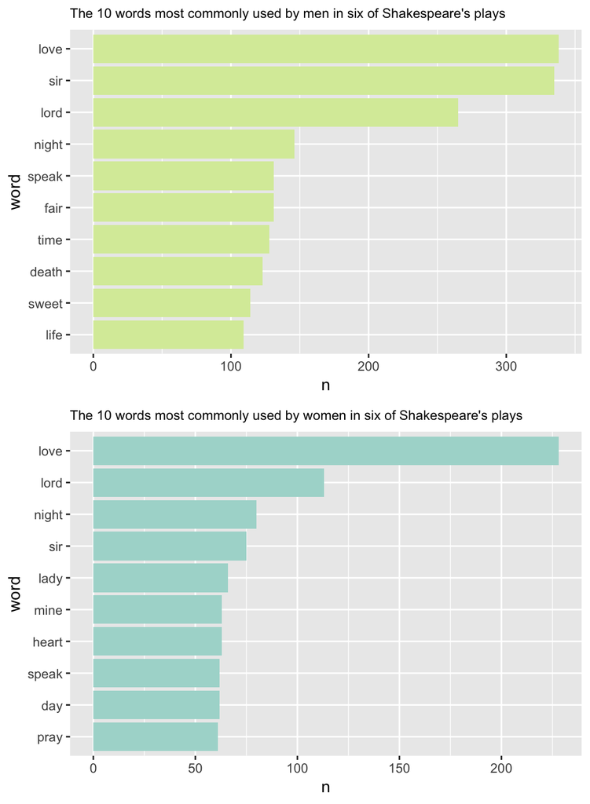

### What words are more likely to be said by a man or a woman?

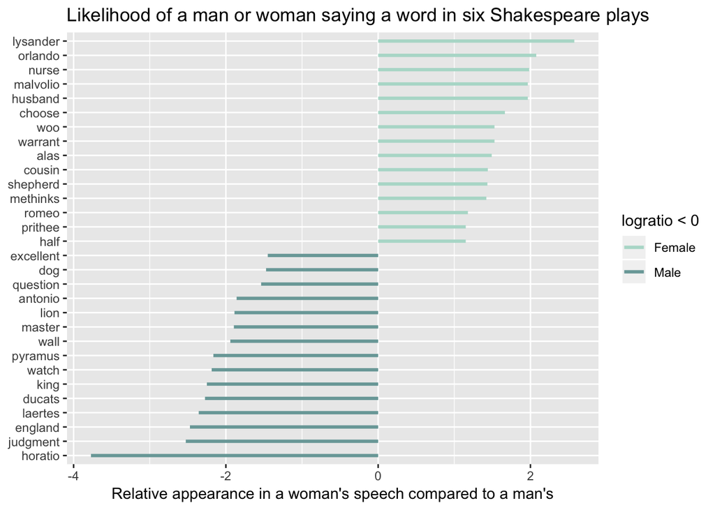

The graphs still contain a fair number of character names; Lysander, Orlando, and amusingly, Malvolio, appear popular with the women. Rosalind and Celia discuss Orlando by name far more than any man in the play does. Lysander declares his love to two women, both of whom refer to him by name quite often. While Malvolio is far from the object of anyone’s desire, Olivia calls him by name quite often, and his interactions with male characters are limited to being ridiculed by Sir Andrew and Sir Toby. Romeo also makes this list - Romeo was actually the 12th or 13th most spoken word by women in total, possibly because Juliet is in the habit of saying his name rather often (“O Romeo, Romeo! Wherefore art thou Romeo?”, Romeo and Juliet, II.ii.33). As for Horatio, who tops the list for men, he speaks to and is addressed by no one besides Hamlet; therefore, it’s very unlikely dialogue from a woman will contain his name. And Antonio, in both cases, is not interested in women, so it is unlikely he will be addressed or referred to by one. The fact that women are more likely to say “woo” strengthens the argument that their involvement in plot is often only romantically, or toward a romantic end. Men are more likely to say more “serious” words, such as “king,” “master,” “judgement” and “question.”

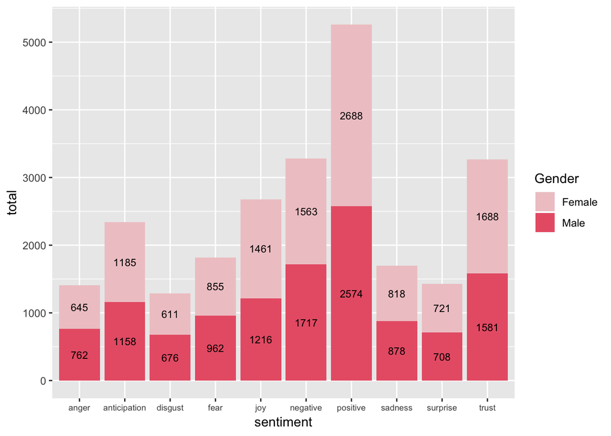

### Sentiment analysis: what do men and women feel?

The graph above uses a sentiment lexicon to partition words into eight emotion categories. The lexicon is modern English, so some words’ connotations are very different from they were in Shakespeare’s time. The graph uses word values that have been proportioned per the number of words analyzed for both men and women. Interesting insights that came to light:

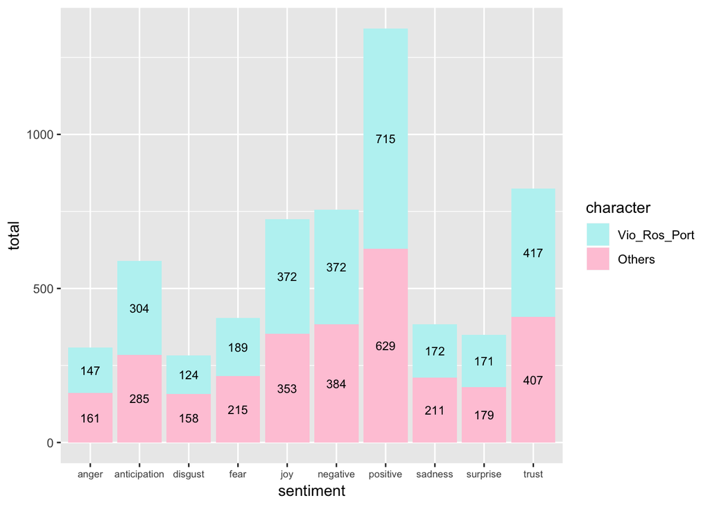

### Do Rosalind, Viola and Portia, disguised as men, show different speech patterns from other women?

To answer this question, I split the female-character corpus into two; one contains all of Rosalind and Viola’s words, as well as Portia’s when she is disguised as a man. The other contains the speech of all other female characters. I ran sentiment analysis on the two corpuses and made their results proportional to each other. The results are recorded in the graph; much as I dislike gendered color coding, I’ve done that here to make it less confusing.

This is quite a specific question, and thins the corpus quite significantly, so I was aware it might not lead to a discovery. However, it did, in that showed the opposite of what might have been expected given the male/female trend. These three women are more positive than the others, expressing more positive emotion and less negative emotion. However, this is likely because they are in comedies, and play very self-assured men always ready with a quip or an argument. They show very little disgust and fear, and, despite Rosalind and Viola’s feminine yearnings for Orlando and Orsino being factored in - it was quite impossible to split the corpus in their cases, as they continuously alternate between playing men and women - they show significantly less sadness than other women.

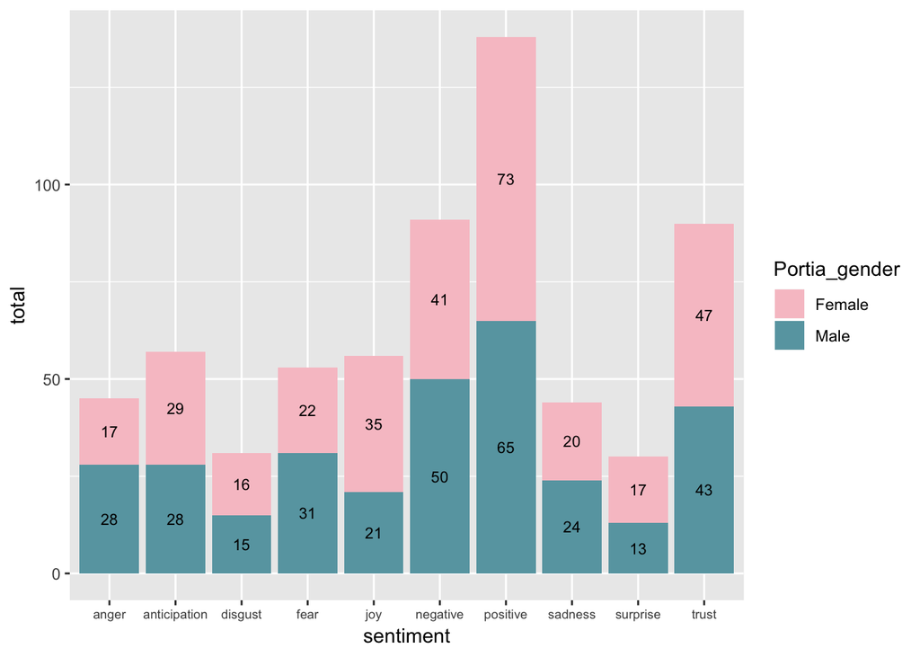

### Does Portia speak differently / use different words when she’s playing a man?

Since Portia’s time as a man is more easily isolated, I decided to focus on her for a bit, at the risk of thinning the corpus into oblivion. I plotted her sentiments as a man against hers as a woman, and found, this time, that her language was significantly different for the two cases, better matching the male/female trend than the previous analysis did. This shows that Rosalind and Viola’s intermittent female language interfered with sentiment plotting, skewing it in an unprecedented direction.

### Conclusion:

The question I asked was very broad, so the conclusions that can be reached are similarly so.

- Firstly, and unsurprisingly, men spoke a great deal more than women, but each woman character spoke a larger share of significant words.
- A recurring conclusion seen in each analysis was women’s greater use of and preoccupation with love language than men. From “woo” and “husband” appearing in women’s likelihood graphs, with “wife” absent from the men’s but “king” and “master” being present, it also became clear that both men and women talk more about men than women. In fact, it’s possible some of these plays do not pass the Bechdel Test - more advanced NLP could probably devise a way to test this out!
- The sentiment analysis is certainly colored by the fact that language has changed greatly since Shakespeare’s time, but the male/female trends it depicts are still valid, since each gender’s words would be equally affected.

The two case studies, Portia’s in particular, served to back up the male/female sentiment analysis in different ways. The analysis of Viola, Portia, and Rosalind showed that Viola and Rosalind’s fluid genders flawed their categorization as “men” and led to graphs that went against the original trend. Portia’s analysis, however, supported the original trend observed, since her character’s lines were easily bisected into male and female. This essay serves as an exploratory starting point for more exhaustive and intensive quantitative analysis of gender in Shakespeare. While Shakespeare plays with the fluidity of gender in his plays, it remains that hidden beneath some overarching similarities (the first four words in the frequency analysis) in the language he uses, there are important differences in the words he gives men and women.